# Time Series Assignment 1

Alvaro Gonzalez Fernandez y Jaime Hurtado de Mendoza Sastre

February 22, 2019

Loading libraries:

```r
library("fpp")
library("rugarch")
library("e1071")
```

# 1 Data Analysis

Problem 1.- The aim of this problem is to analyze the returns of the time series given by the FCHI daily returns.

Firstly the data has to be loaded:

```r
fchi <- read.csv("^FCHI.csv", dec = ".")
head(fchi)
```

```
##         Date        Open        High         Low       Close   Adj.Close
## 1 1990-03-01 1836.000000 1838.000000 1827.000000 1832.000000 1832.000000
## 2 1990-03-02 1831.000000 1860.000000 1831.000000 1860.000000 1860.000000
## 3 1990-03-05 1866.000000 1874.000000 1862.000000 1874.000000 1874.000000
## 4 1990-03-06 1869.000000 1875.000000 1866.000000 1872.000000 1872.000000
## 5 1990-03-07 1874.000000 1881.000000 1874.000000 1880.000000 1880.000000
## 6 1990-03-08 1891.000000 1923.000000 1891.000000 1917.000000 1917.000000
##   Volume
## 1      0
## 2      0
## 3      0
## 4      0
## 5      0
## 6      0
```

From all the variables available in the dataset we only care about the daily returns which are computed as follows: $r_t = 100 \times (ln(p_t)-ln(p_{t-1}))$, where $p_t$ and $p_{t-1}$ represent the adjusted closing price at times $t$ and $t-1$ respectively, and the whole expression is multiplied by $100$ so that it is in percentage. Below, the implementation of a function as well as the call to it in order to obtain the daily returns are presented.

```r
adjClose <- function(prices) {
  rt <- ts(numeric(length(prices)), frequency = 365, start = as.numeric(format(as.Date("1990-01-04"), "%j")))
  for (i in 1:length(prices)) {
    if (i == 1) {
      rt[i] <- 0
    }
    else {
      rt[i] <- 100*(log(prices[i])-log(prices[i-1]))
    }
  }
  return(rt)
}

fchiRet <- adjClose(as.numeric(fchi$Adj.Close))
```

Once the returns have been computed it seems interesting to visualize the time series.

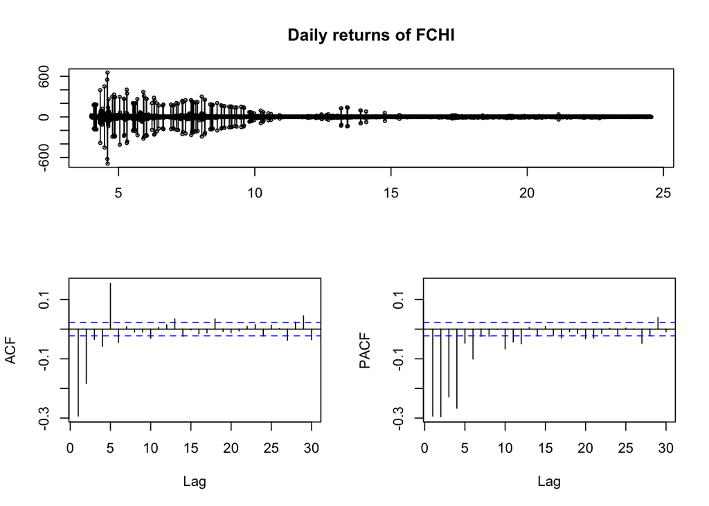

```r
tsdisplay(fchiRet, lag.max = 30, main="Daily returns of FCHI")
```

In the plots above we can see the daily returns for the FCHI as well as the autocorrelogram and the partial autocorrelogram of these daily returns. The autocorrelogram shows high autocorrelation for observations up to 2 days before and abnormally high for observation 5. Either way, thanks to these graphs we can see that the data is stationary.

Once the data has been loaded and visualize, now we will obtain the four main moments of a probability distribution which are its mean, variance, kurtosis and skewness.

```r
moments <- function(data) {
  return(c(paste("Mean: ", mean(data)), paste("Standard deviation: ", sd(data)), paste("Kurtosis: ", kurtosis(data)), paste("Skewness: ", skewness(data))))
}

moments(fchiRet)
```

```
## [1] "Mean:  0.0363566088886912"
## [2] "Standard deviation:  36.4313797461132"
## [3] "Kurtosis:  91.6613907532007"
## [4] "Skewness:  -0.301664329154751"
```

As expected, the mean of the returns is quite close to zero. The variance in this case is very high, which is not usual for the kind of data we are dealing with. Moreover the variance is quite high for what it could be expected for this kind of data as normally the variance for the daily returns is quite close to zero. The value of the skweness is negative and similar to what it could be expected when looking at daily returns. The sign of the skweness indicates that the left tale of the distribution is larger than the right tale. Finally, the Kurtosis, even though for this type of data normally is large, in this case we can observe an abnormally high value.

# 2 Univariate GARCH models.

The aim is to fit a GARCH-type model to a financial time series returns, more specifically to the FCHI time series.

## 2.1 Fit a GARCH(1,1) model with Gaussian errors to the daily returns and comment on the implied volatility persistance obtained with this model.

Even though the mean is already very small is quite common to subtract it from the returns to model the volatility, therefore, we’ll do so:

```r
fchiRet2 <- fchiRet - mean(fchiRet)
moments(fchiRet2)
```

```
## [1] "Mean:  -1.07025984986625e-16"
## [2] "Standard deviation:  36.4313797461132"
## [3] "Kurtosis:  91.6613907532007"
## [4] "Skewness:  -0.301664329154751"
```

As it can be seen we’ve made the mean of the series zero.

Now in order to fit the garch model, firstly the some parameters have to be specified, as it is done in the following section:

```r
fchiRetSpec <- ugarchspec(variance.model = list(garchOrder=c(1,1)), mean.model = list(armaOrder = c(0,0)))
```

Here we have specified that the variance will be modeled as a garch of order 1,1 and the mean as an arma model of order 0,0, which means that no model will be fit for the mean as it is constant.

```r
fchiRetFit <- ugarchfit(spec = fchiRetSpec, fchiRet2)
fchiRetFit
```

```
##
## *---------------------------------*
## *          GARCH Model Fit        *
## *---------------------------------*
##
## Conditional Variance Dynamics
## -----------------------------------
## GARCH Model  : sGARCH(1,1)
## Mean Model   : ARFIMA(0,0,0)
## Distribution : norm
##
## Optimal Parameters
## ------------------------------------
##         Estimate  Std. Error   t value Pr(>|t|)
## mu      0.000000    0.030824    0.0000        1
## omega   0.007076    0.001390    5.0914        0
## alpha1  0.016263    0.000239   67.9651        0
## beta1   0.982736    0.000126 7791.5432        0
##
## Robust Standard Errors:
##         Estimate  Std. Error   t value Pr(>|t|)
## mu      0.000000    0.023837    0.0000  1.00000
## omega   0.007076    0.005685    1.2448  0.21322
## alpha1  0.016263    0.002065    7.8756  0.00000
## beta1   0.982736    0.000520 1888.5550  0.00000
##
## LogLikelihood : -26955.61
##
## Information Criteria
## ------------------------------------
##
## Akaike       7.1864
## Bayes        7.1900
## Shibata      7.1864
## Hannan-Quinn 7.1876
##
## Weighted Ljung-Box Test on Standardized Residuals
## ------------------------------------
##                         statistic p-value
## Lag[1]                      176.4       0
```

[output cut: 37 more lines]

```
## Negative Sign Bias   1.305 1.919e-01
## Positive Sign Bias   7.758 9.779e-15 ***
## Joint Effect        61.910 2.297e-13 ***
##
##
## Adjusted Pearson Goodness-of-Fit Test:
## ------------------------------------
##   group statistic p-value(g-1)
## 1    20      6837            0
## 2    30      7152            0
## 3    40      7385            0
## 4    50      7484            0
##
##
## Elapsed time : 0.3151441
```

From this fit we obtain that the volatility persistance is 0.982736, which is quite high, and means that there is not too much change in the volatility with time as it is almost the same as the one observed one step before.

## 2.2 Is the model able to fit the characteristics of the data (mainly asymmetry)? Use a test tu justify your answer.

Firstly we’ll visualize again the time series and the results and plot of the model.

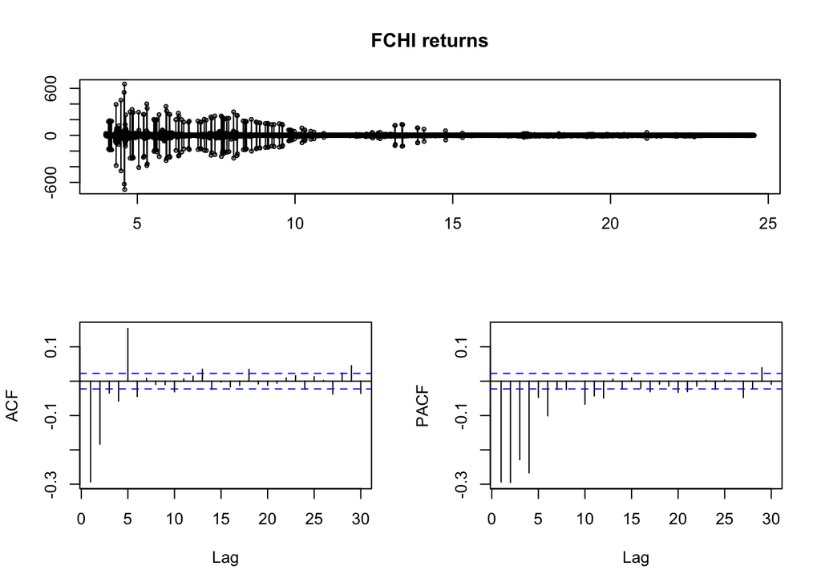

```r
tsdisplay(fchiRet2, lag.max = 30, main="FCHI returns")
```

It is imoportant to note that the dates shown in these plots are not the ones that are being used and is just a bad representation and interpretation from the labels in the plots.

```
##
## please wait...calculating quantiles...
```

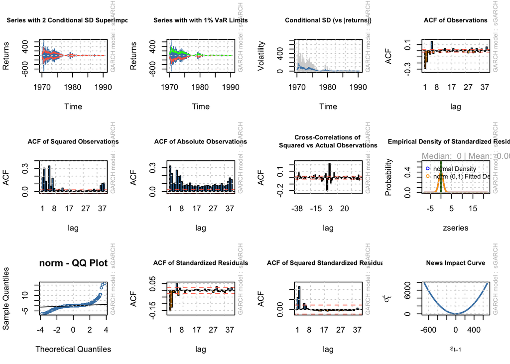

```r
plot(fchiRetFit, which = "all")
```

From these plots specially those concerining the distribution of the errors, we can see that the time series is not symmetric as surprisingly, the positive returns have a higher effect than the negative ones. Graphically the best way to see this is probably by looking at the distribution of the errors which are positive or right skewed (unusual).

From the results of fitting the model, we can see the Engle and Ng test.

```r
signbias(fchiRetFit)
```

```
##                      t-value         prob sig
## Sign Bias           1.641204 1.007970e-01
## Negative Sign Bias  1.305149 1.918822e-01
## Positive Sign Bias  7.757858 9.778810e-15 ***
## Joint Effect       61.910063 2.296538e-13 ***
```

Indeed, we can see that the sign bias is positive which makes sense to what we’ve seen on the residuals. Once again, it is important to remark that this is unusual in financial time series as normally the negative effects have higher impact than the positive ones.

## 2.3 According to the previous answer, fit a GARCH-type model to your data and compare its estimation results to those obtained with the GARCH(1,1).

A GARCH-type model that provides a better fit than the GARCH(1,1) model would be one that is able to model the asymmetry. We could use either an EGARCH or GJR.

We’ll fit an GJR model to the time series with errors following an Normal distribution.

```r
fchiRetSpecAsym <- ugarchspec(variance.model = list(model = "gjrGARCH", garchOrder = c(1,1)), mean.model = list(armaOrder = c(0,0)), distribution.model = "norm")
fchiRetFitAsym <- ugarchfit(spec = fchiRetSpecAsym, fchiRet2)
fchiRetFitAsym
```

```
##
## *---------------------------------*
## *          GARCH Model Fit        *
## *---------------------------------*
##
## Conditional Variance Dynamics
## -----------------------------------
## GARCH Model  : gjrGARCH(1,1)
## Mean Model   : ARFIMA(0,0,0)
## Distribution : norm
##
## Optimal Parameters
## ------------------------------------
##         Estimate  Std. Error   t value Pr(>|t|)
## mu      0.000000    0.033636    0.0000        1
## omega   0.012043    0.001894    6.3599        0
## alpha1  0.027300    0.001044   26.1460        0
## beta1   0.982146    0.000126 7811.5790        0
## gamma1 -0.020974    0.002072  -10.1230        0
##
## Robust Standard Errors:
##         Estimate  Std. Error   t value Pr(>|t|)
## mu      0.000000    0.065565    0.0000 1.000000
## omega   0.012043    0.008483    1.4196 0.155717
## alpha1  0.027300    0.005854    4.6637 0.000003
## beta1   0.982146    0.000468 2098.2021 0.000000
## gamma1 -0.020974    0.009439   -2.2220 0.026284
##
## LogLikelihood : -26901.07
##
## Information Criteria
## ------------------------------------
##
## Akaike       7.1721
## Bayes        7.1767
## Shibata      7.1721
## Hannan-Quinn 7.1737
##
## Weighted Ljung-Box Test on Standardized Residuals
## ------------------------------------
```

[output cut: 40 more lines]

```
## Negative Sign Bias   1.235 2.169e-01
## Positive Sign Bias   6.527 7.134e-11 ***
## Joint Effect        44.169 1.389e-09 ***
##
##
## Adjusted Pearson Goodness-of-Fit Test:
## ------------------------------------
##   group statistic p-value(g-1)
## 1    20      6904            0
## 2    30      7255            0
## 3    40      7475            0
## 4    50      7577            0
##
##
## Elapsed time : 0.8334861
```

```
##
## please wait...calculating quantiles...
```

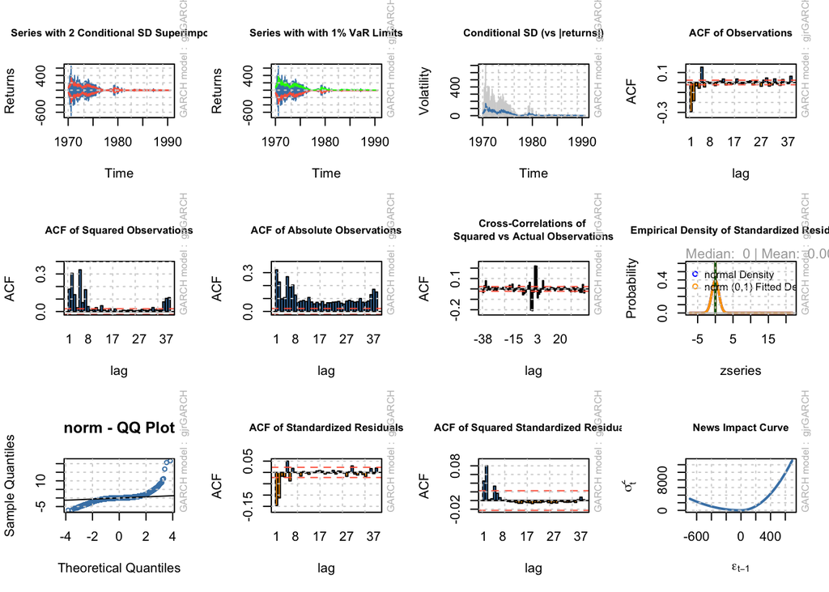

```r
plot(fchiRetFitAsym, which = "all")
```

We can see from the NIC that this model captures better the positive asymmetriy commented before.

Now we’ll compare the unconditional mean and variances of both models, as well as their forecasts.

GARCH(1,1)

```r
c(paste("Unconditional mean: ",uncmean(fchiRetFit)),paste("Unconditional variance: ", uncvariance(fchiRetFit)))
```

```
## [1] "Unconditional mean:  -1.06923411577562e-14"
## [2] "Unconditional variance:  7.06747992425006"
```

Threshold GARCH(1,1) - GJR

```r
c(paste("Unconditional mean: ",uncmean(fchiRetFitAsym)),paste("Unconditional variance: ", uncvariance(fchiRetFitAsym)))
```

```
## [1] "Unconditional mean:  -1.07025666113103e-14"
## [2] "Unconditional variance:  11.5667866115021"
```

```r
fcRet <- ugarchforecast(fchiRetFit)
fcRet
```

```
##
## *------------------------------------*
## *       GARCH Model Forecast         *
## *------------------------------------*
## Model: sGARCH
## Horizon: 10
## Roll Steps: 0
## Out of Sample: 0
##
## 0-roll forecast [T0=1990-07-18 02:00:00]:
##          Series Sigma
## T+1  -1.069e-14 1.320
## T+2  -1.069e-14 1.322
## T+3  -1.069e-14 1.324
## T+4  -1.069e-14 1.326
## T+5  -1.069e-14 1.328
## T+6  -1.069e-14 1.330
## T+7  -1.069e-14 1.332
## T+8  -1.069e-14 1.334
## T+9  -1.069e-14 1.336
## T+10 -1.069e-14 1.338
```

```r
fcRetAsym <- ugarchforecast(fchiRetFitAsym)
fcRetAsym
```

```
##
## *------------------------------------*
## *       GARCH Model Forecast         *
## *------------------------------------*
## Model: gjrGARCH
## Horizon: 10
## Roll Steps: 0
## Out of Sample: 0
##
## 0-roll forecast [T0=1990-07-18 02:00:00]:
##         Series Sigma
## T+1  -1.07e-14 1.430
## T+2  -1.07e-14 1.434
## T+3  -1.07e-14 1.437
## T+4  -1.07e-14 1.440
## T+5  -1.07e-14 1.444
## T+6  -1.07e-14 1.447
## T+7  -1.07e-14 1.451
## T+8  -1.07e-14 1.454
## T+9  -1.07e-14 1.457
## T+10 -1.07e-14 1.461
```

As expected the later model predicts a largewr variance.

## 2.4 Plot the NIC of the chosen model and explain it.

Even though the News Impact Curve has already been plotted for both models we’ll plot it again to see how the GJR captures better the fact that the variance (volatility) of this time series changes more when there is a positive change than when there is a negative one.

GARCH(1,1)

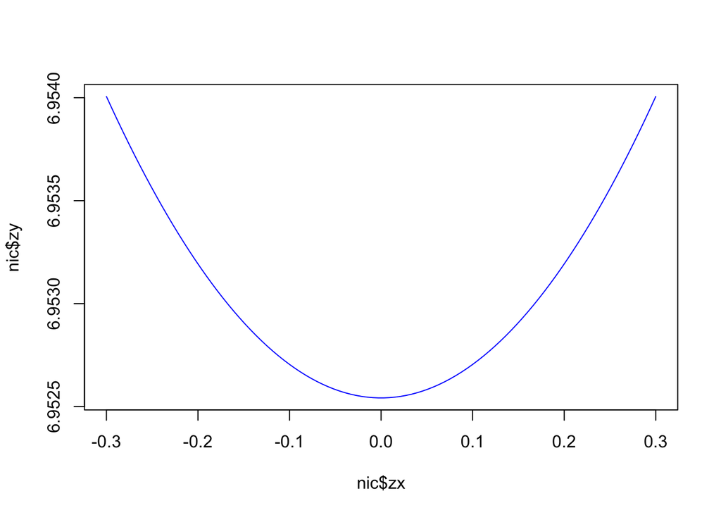

```r
nic <- newsimpact(fchiRetFit)
plot(nic$zx, nic$zy, type="l", col="blue")
```

GJR

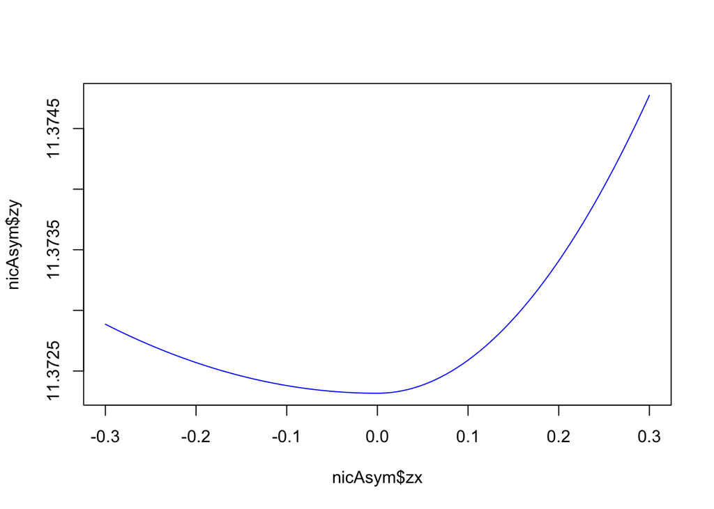

```r
nicAsym <- newsimpact(fchiRetFitAsym)
plot(nicAsym$zx, nicAsym$zy, type="l", col="blue")
```

As it has been seen before, the volatility changes more when there are positive changes than when there are negative changes in the time series. This is captured quite well by the GJR model as it can be seen on the previous graph.